# Uso de R en el desarrollo de ACB

Saúl Torres Ortega

November 2016

# Introducción

En este taller se verá cómo aplicar el lenguaje de programación R a:

- La realización de un Análisis Coste-Beneficio (económico y/o financiero).
- La realización de un análisis de sensibilidad.
- La realización de un análisis de riesgo.

# R

# Qué es R?

R es un proyecto que conjuga dos aspectos diferentes (aunque íntimamente relacionados): por un lado es un lenguaje de programación, y por otro es un entorno de trabajo.

Su entorno de trabajo (el conjunto de ventanas y menús que normalmente asociamos a un programa) puede resultar a veces “poco amigable”. Es por ello que han surgido otros programas que nos proporcionan un entorno de trabajo más atractivo y funcional. Uno de estos programas es RStudio.

# Descargar e instalar R

Accedemos a la web de R y descargamos la última versión disponible.

- [R Project](https://www.r-project.org/)
- [Link de descargas](https://cran.r-project.org/)

Una vez hemos descargado el archivo, le ejecutamos e instalamos.

# Descargar e instalar RStudio

Al igual que con R, accedemos a la web de RStudio y descargamos la última versión disponible. Para nuestros propósitos, descargaremos la versión “RStudio Desktop - Open Source Edition”.

- [RStudio](https://www.rstudio.com/)
- [Link de descargas](https://www.rstudio.com/products/RStudio/#Desktop)

Una vez hemos descargado el archivo, le ejecutamos e instalamos.

# Básicos de R

Existen tres libros que sirven como buena base de aprendizaje para cualquier novato que aterrice en R. En todos ellos se tratan los primeros pasos y sirven para empezar a trastear.

- [R by Example](http://www.springer.com/br/book/9781461413646)
- [R in a Nutshell](http://shop.oreilly.com/product/9780596801717.do)
- [R Cookbook](http://www.cookbook-r.com/)

Igualmente hay páginas gratuitas con interesantes tutoriales de iniciación, como por ejemplo [este](http://www.r-bloggers.com/how-to-learn-r-2/).

Tenéis algunos links más sobre R [aquí](https://sites.google.com/site/saultorresortega/r).

# Caso práctico a utilizar

# Skjern River

En este taller vamos a aplicar la metodología del análisis coste-beneficio a un determinado proyecto de inversión, y los vamos a realizar utilizando en todo momento el lenguaje R. Vamos a analizar el **Caso Práctico #5: “Cost-benefit analysis of the Skjern River restoration project”**. Si no dispones de él puedes descargarlo de aquí: https://sites.google.com/site/saultorresortega/docencia/epsp

# Simplificación del caso

| Concept | TOTAL | ANNUAL |
| --- | --- | --- |
| **COSTS** |  |  |
| Construction costs | 145.000.000 | - |
| Operat. Maintenan. | - | 860.000 |
| Forgone rents | - | 3.000.000 |
| **BENEFITS** |  |  |
| Improved land | - | 860.000 |
| Flood risk | - | 30.000 |
| Hunting | - | 500.000 |

# Código ACB-01

# Definición de costes

```r
# COSTES #
# ------ #
# Construction costs
cons.cost <- 145000000
# Años 1998, 1999, 2000, 2001, 2002
cons.cost.dist <- c(0.05, 0.17, 0.33, 0.25, 0.20)
# Operation and maintenance
oper.cost <- 860000
# Forgone land rent
land.cost <- 3000000
```

# Definición de ingresos

```r
# INGRESOS #
# -------- #
# Improved land alocation
land.inco <- 860000
#Flood risk
flood.inco <- 30000
# Hunting
hunt.inco <- 500000
```

# Definición de parámetros básicos

```r
# PARÁMETROS BÁSICOS #
# ------------------ #
# Tasa de descuento
disc.rate <- 0.03
# Horizonte temporal
hozt.temp <- 25
```

# Construcción de series temporales

```r
# SERIES TEMPORALES #
# ----------------- #
# Años
year.vector <- c(1:hozt.temp)
# Construction costs
cons.cost.vector <- rep(0, hozt.temp)
for (i in 1:length(cons.cost.dist)) {
  cons.cost.vector[i] <- cons.cost.dist[i]*cons.cost
}
# Operation and maintenance
oper.cost.vector <- rep(0, hozt.temp)
for (i in length(cons.cost.dist+1):hozt.temp) {
  oper.cost.vector[i] <- oper.cost
}
# Forgone land rent
land.cost.vector <- rep(0, hozt.temp)
for (i in length(cons.cost.dist+1):hozt.temp) {
  land.cost.vector[i] <- land.cost
}
# Improved land alocation
land.inco.vector <- rep(0, hozt.temp)
for (i in length(cons.cost.dist+1):hozt.temp) {
  land.inco.vector[i] <- land.inco
}
#Flood risk
flood.inco.vector <- rep(0, hozt.temp)
for (i in length(cons.cost.dist+1):hozt.temp) {
  flood.inco.vector[i] <- flood.inco
}
# Hunting
hunt.inco.vector <- rep(0, hozt.temp)
for (i in length(cons.cost.dist+1):hozt.temp) {
  hunt.inco.vector[i] <- hunt.inco
}
```

# Beneficios

```r
# --------------------- #
# BENEFITS / Beneficios #
# --------------------- #
ben.vector <- rep(0, hozt.temp)
netben.vector <- rep(0, hozt.temp)
for (i in (1):(hozt.temp)) {
  ben.vector[i] <- land.inco.vector[i]+flood.inco.vector[i]+hunt.inco.vector[i]-
                   cons.cost.vector[i]-oper.cost.vector[i]-land.cost.vector[i]
  netben.vector[i] <- ben.vector[i]/((1+disc.rate)^i)
}
```

# Cálculo del VAN

```r
# --------------------- #
# NPV + IRR / VAN + TIR #
# --------------------- #
npv <- sum(netben.vector)
# To calculate irr, both negative and positive values in benefits
library(FinCal)
#irr <- irr(ben.vector)

npv.result <- c(npv) #, irr)
```

```
## [1] -165115904
```

# Código ACB-02

# Definición de la función npv.fun

```r
# ---------------------------------- #
# 1.- FUNCIÓN VALOR ACTUALIZADO NETO #
# ---------------------------------- #

npv.fun <- function (vector.data) {
  # VECTOR DATA : vector en el cual se incluyan los parámetros siguientes
  # (fijar, dejar como parámetros variables según deseos)
  # (se introducen como vector para el posterior análisis de sensibilidad)

  # COSTES #
  # ------ #
  # Construction costs
  cons.cost <- vector.data[1]
  # Años 1998, 1999, 2000, 2001, 2002
  cons.cost.dist <- c(0.05, 0.17, 0.33, 0.25, 0.20)
  # Operation and maintenance
  oper.cost <- vector.data[2]
  # Forgone land rent
  land.cost <- vector.data[3]


  # INGRESOS #
  # -------- #
  # Improved land alocation
  land.inco <- vector.data[4]
  #Flood risk
  flood.inco <- vector.data[5]
  # Hunting
  hunt.inco <- vector.data[6]


  # PARÁMETROS BÁSICOS #
  # ------------------ #
  # Tasa de descuento
  disc.rate <- vector.data[7]
  # Horizonte temporal
  hozt.temp <- vector.data[8]


  # SERIES TEMPORALES #
  # ----------------- #
  # Años
  year.vector <- c(1:hozt.temp)

  # Construction costs
  cons.cost.vector <- rep(0, hozt.temp)
  for (i in 1:length(cons.cost.dist)) {
    cons.cost.vector[i] <- cons.cost.dist[i]*cons.cost
  }
  # Operation and maintenance
  oper.cost.vector <- rep(0, hozt.temp)
  for (i in length(cons.cost.dist+1):hozt.temp) {
    oper.cost.vector[i] <- oper.cost
  }
  # Forgone land rent
  land.cost.vector <- rep(0, hozt.temp)
  for (i in length(cons.cost.dist+1):hozt.temp) {
    land.cost.vector[i] <- land.cost
  }

  # Improved land alocation
  land.inco.vector <- rep(0, hozt.temp)
  for (i in length(cons.cost.dist+1):hozt.temp) {
    land.inco.vector[i] <- land.inco
  }
  #Flood risk
  flood.inco.vector <- rep(0, hozt.temp)
  for (i in length(cons.cost.dist+1):hozt.temp) {
    flood.inco.vector[i] <- flood.inco
  }
  # Hunting
  hunt.inco.vector <- rep(0, hozt.temp)
  for (i in length(cons.cost.dist+1):hozt.temp) {
    hunt.inco.vector[i] <- hunt.inco
  }

  # --------------------- #
  # BENEFITS / Beneficios #
  # --------------------- #
  ben.vector <- rep(0, hozt.temp)
  netben.vector <- rep(0, hozt.temp)
  for (i in (1):(hozt.temp)) {
    ben.vector[i] <- land.inco.vector[i]+flood.inco.vector[i]+hunt.inco.vector[i]-
      cons.cost.vector[i]-oper.cost.vector[i]-land.cost.vector[i]
    netben.vector[i] <- ben.vector[i]/((1+disc.rate)^i)
  }

  # --------------------- #
  # NPV + IRR / VAN + TIR #
  # --------------------- #
  npv <- sum(netben.vector)
  npv.result <- npv
  npv.result
}
```

# Definición de la función anal.sensit

```r
# ------------------------------------ #
# 2.- FUNCIÓN ANÁLISIS DE SENSIBILIDAD #
# ------------------------------------ #

anal.sensit <- function( model, pars.vector.values, pars.vector.names) {
  # Inputs:
      # función modelo
      # vector con los parámetros base del modelo
      # vector con los nombres de los parámetros
  pars.dim <- length(pars.vector.values)

  # Steps del análisis. -5%, -2.5%, 0, 2.5%, 5%
  steps <- c(-0.05, -0.025, 0, 0.025, 0.05)
  abs.df <- data.frame(steps)
  perc.df <- data.frame(steps)

  column.names <- rep(0, pars.dim+1)
  column.names[1] = "Change in parameter"
  # Este ciclo está ajustado para cinco steps (a, b, c, d, e)
  for (i in 1:pars.dim){
    column.names[i+1] = pars.vector.names[i]
    pars.vector.sensit <- pars.vector.values
    pars.vector.sensit[i] <- pars.vector.values[i]*(1+steps[1])
    a <- model(pars.vector.sensit)
    pars.vector.sensit[i] <- pars.vector.values[i]*(1+steps[2])
    b <- model(pars.vector.sensit)
    pars.vector.sensit[i] <- pars.vector.values[i]*(1+steps[3])
    c <- model(pars.vector.sensit)
    pars.vector.sensit[i] <- pars.vector.values[i]*(1+steps[4])
    d <- model(pars.vector.sensit)
    pars.vector.sensit[i] <- pars.vector.values[i]*(1+steps[5])
    e <- model(pars.vector.sensit)
    abs.df <- cbind(abs.df, c(a,b,c,d,e))
    perc.df <- cbind(perc.df, c(100*(a-c)/c, 100*(b-c)/c, 0, 100*(d-c)/c, 100*(e-c)/c))
  }
  colnames(abs.df) <- column.names
  colnames(perc.df) <- column.names
  perc.df
}
```

# Análisis de sensibilidad

```r
# ------------------------------------------ #
# 3.- EJECUCIÓN DEL ANÁLISIS DE SENSIBILIDAD #
# ------------------------------------------ #

# Copiar y pegar para analizar varias alternativas
model_1.param <- c(145000000, 860000, 3000000, 860000, 30000, 500000, 0.03, 25)
model_1.names <- c("cons.cost", "oper.cost", "land.cost",
                   "land.inco", "flood.inco", "hunt.inco",
                   "disc.rate", "hozt.temp")
model_1.sa.df <- anal.sensit(npv.fun, model_1.param, model_1.names)
model_1.sa.df$project <- "model_1"
```

# Gráfico de araña

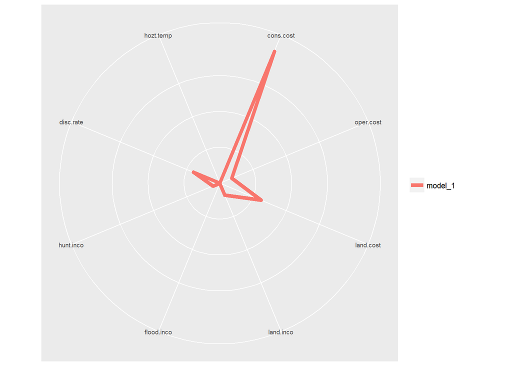

# Análisis de Montecarlo

```r
# ----------------------- #
# 4.- ANÁLISIS MONTECARLO #
# ----------------------- #

model_1.mc.df <- data.frame(npv=numeric(0), irr=numeric(0))
for (i in 1:500) {
  # Distribuciones de probabilidad de cada parámetro
  a <- runif(1, min = 145000000*0.75, max = 145000000*1.25)
  b <- runif(1, min = 860000*0.75, max = 860000*1.25)
  c <- runif(1, min = 3000000*0.75, max = 3000000*1.25)
  d <- runif(1, min = 860000*0.75, max = 860000*1.25)
  e <- runif(1, min = 30000*0.75, max = 30000*1.25)
  f <- runif(1, min = 500000*0.75, max = 500000*1.25)
  g <- runif(1, min = 0.03*0.75, max = 0.03*1.25)
  h <- runif(1, min = 25, max = 25)
  model_1.param <- c(a, b, c, d, e, f, g, h)
  # Llamada a la función y almacenar datos
  model_1.mc.df <- rbind(model_1.mc.df, npv.fun(model_1.param))
}
```

# Función de densidad

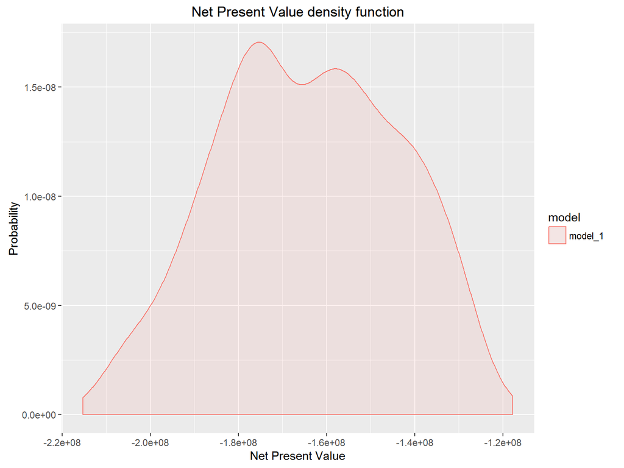

# Histograma

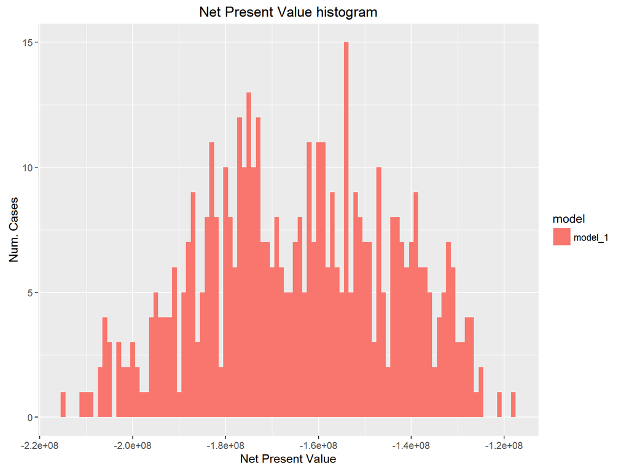

# Función de distribución

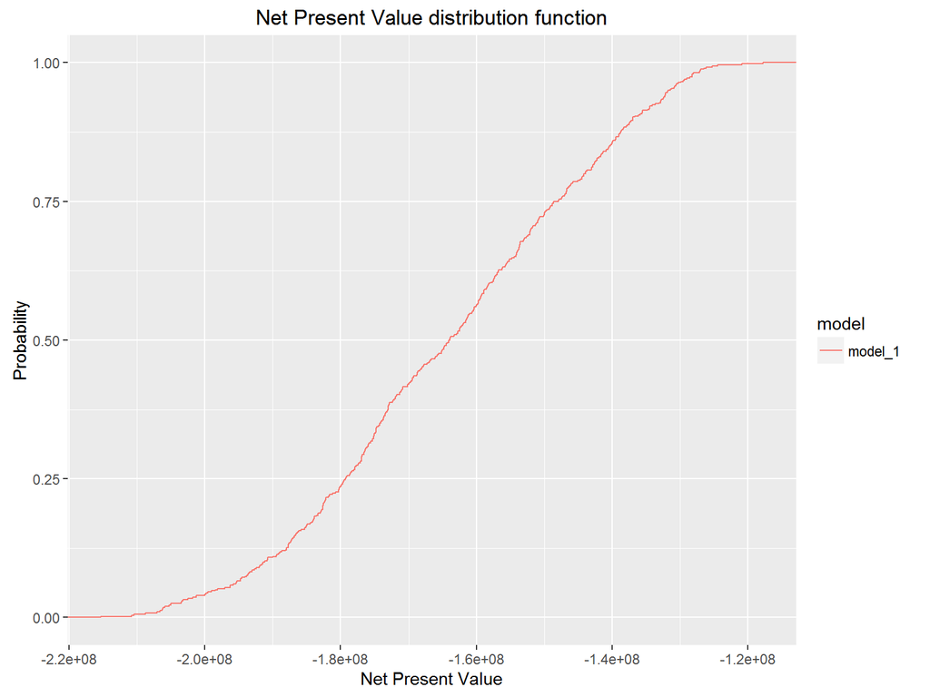